## Summary…

```
## 'data.frame':    1105 obs. of  31 variables:
##  $ q0.1_time             : Date, format: "2017-04-18" "2017-04-18" ...
##  $ q1.1_usefb            : Factor w/ 4 levels "1","2","3","4": 4 1 4 4 4 3 1 4 4 4 ...
##  $ q1.2_useig            : Factor w/ 4 levels "1","2","3","4": 1 2 3 2 1 1 1 1 3 1 ...
##  $ q1.3_usesc            : Factor w/ 4 levels "1","2","3","4": 4 4 3 2 3 1 4 2 2 2 ...
##  $ q2.1_nocare           : Factor w/ 4 levels "1","2","3","4": 1 2 1 2 3 1 2 2 1 1 ...
##  $ q3.1_gender           : Factor w/ 2 levels "kvinde","mand": 1 2 1 2 2 1 2 1 1 2 ...
##  $ q4.1_age              : num  17 17 18 16 17 18 19 18 18 17 ...
##  $ q5.1_digedu           : Factor w/ 2 levels "ja","nej": 2 1 2 1 2 1 2 2 1 2 ...
##  $ q6.1_school           : Factor w/ 15 levels "borupgaard","egedal",..: 12 8 12 8 12 8 12 12 12 12 ...
##  $ q7.1_editedprivacy    : Factor w/ 4 levels "1","2","3","4": 4 2 3 3 2 4 3 3 4 4 ...
##  $ q8.1_freqpost         : Factor w/ 7 levels "1","2","3","4",..: 2 1 1 5 2 2 1 1 5 1 ...
##  $ q8.2_freqsend         : Factor w/ 7 levels "1","2","3","4",..: 7 1 6 6 4 4 4 7 6 6 ...
##  $ q8.3_freqread         : Factor w/ 7 levels "1","2","3","4",..: 6 6 6 6 2 4 6 7 6 6 ...
##  $ q9.1_seecontent       : Factor w/ 4 levels "1","2","3","4": 2 4 3 2 3 2 3 3 3 4 ...
```

[output cut: 18 more lines]

## …Summary continued

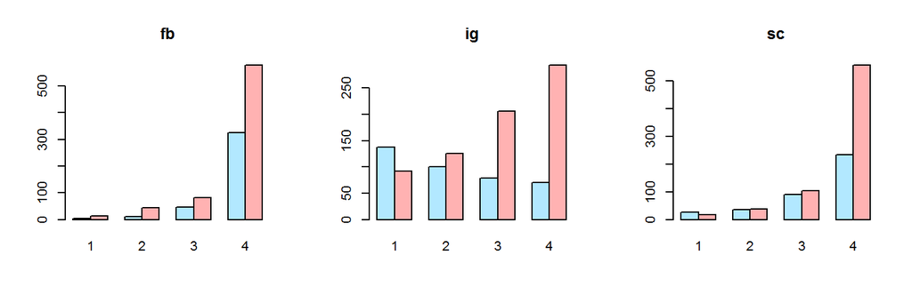

## …Summary continued

## …Summary continued

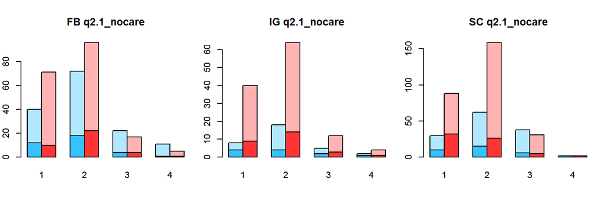

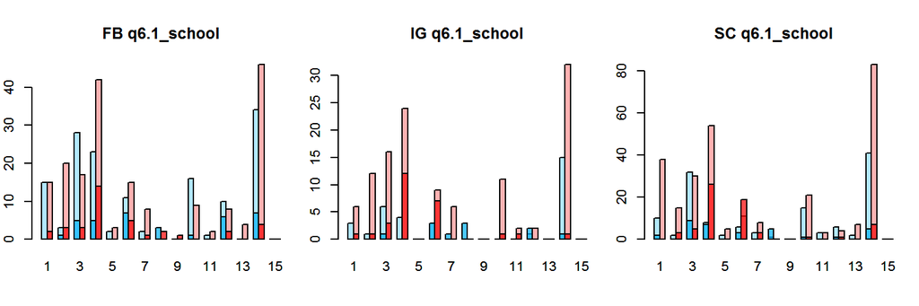

## …Summary continued

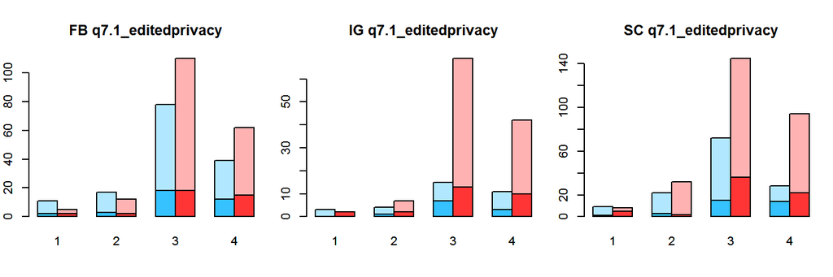

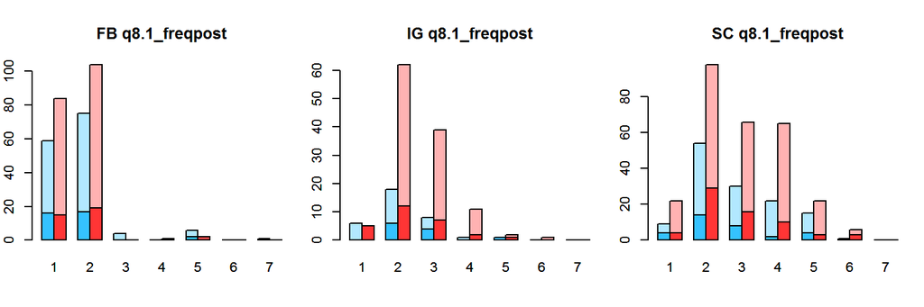

## …Summary continued

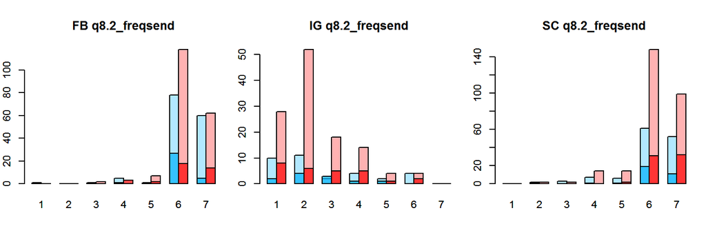

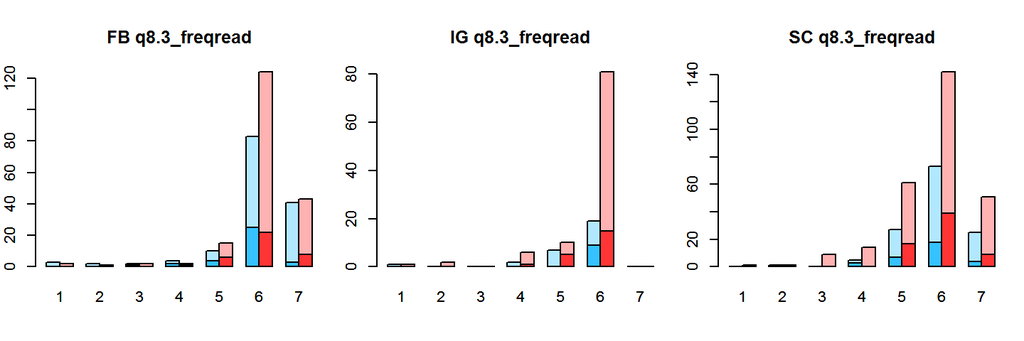

## …Summary continued

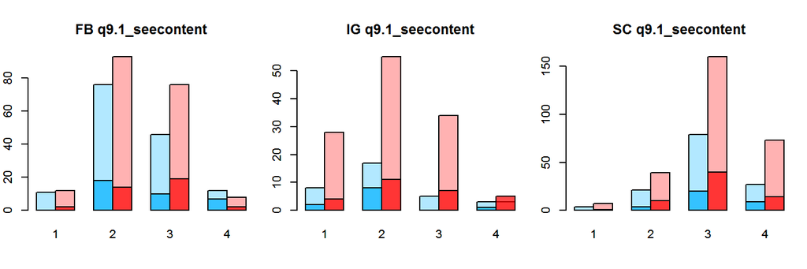

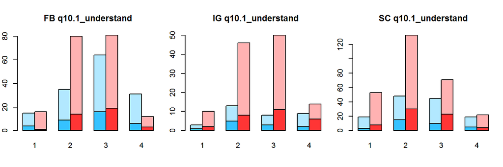

## …Summary continued

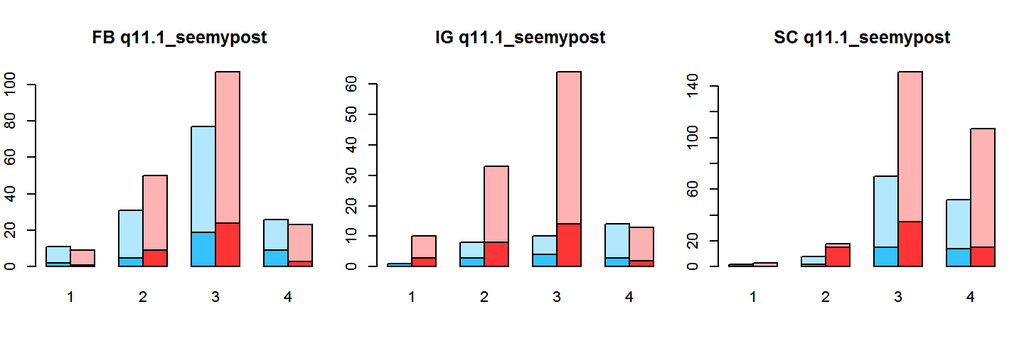

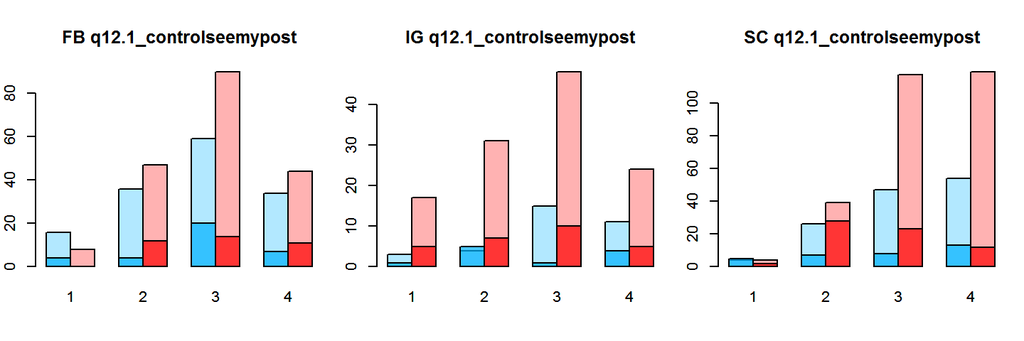

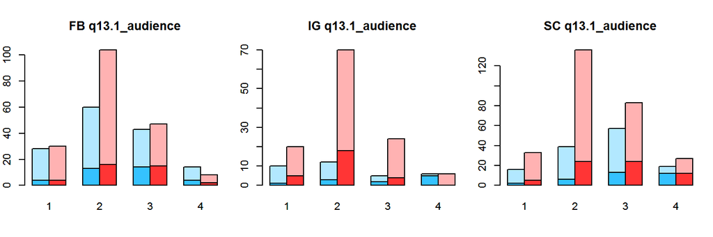

## …Summary continued

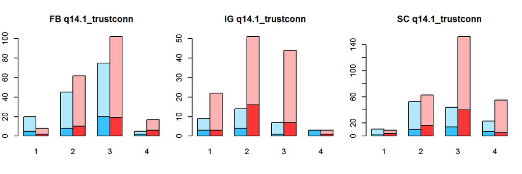

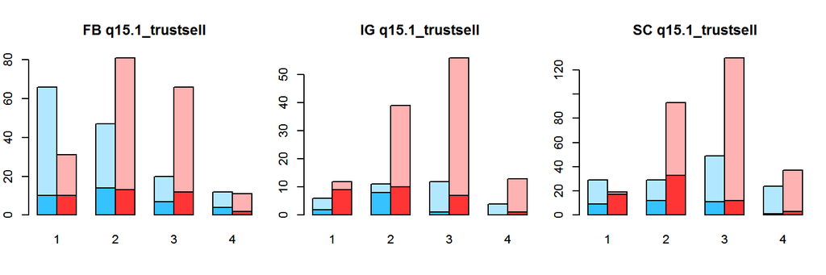

## …Summary continued

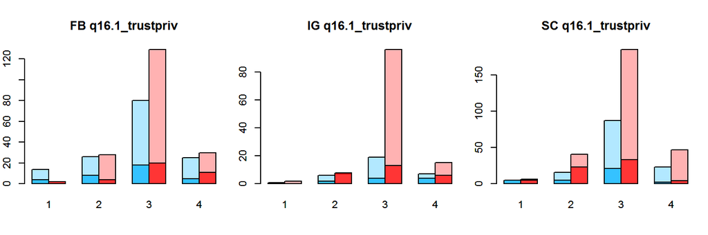

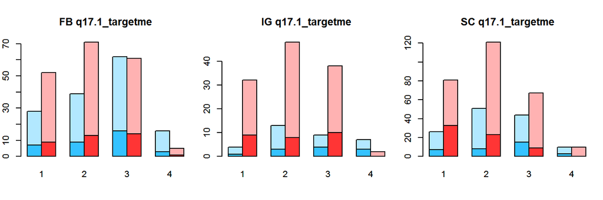

## …Summary continued

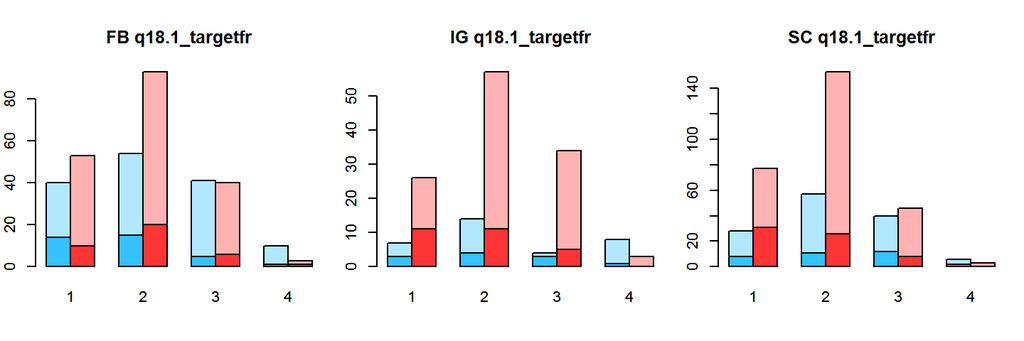

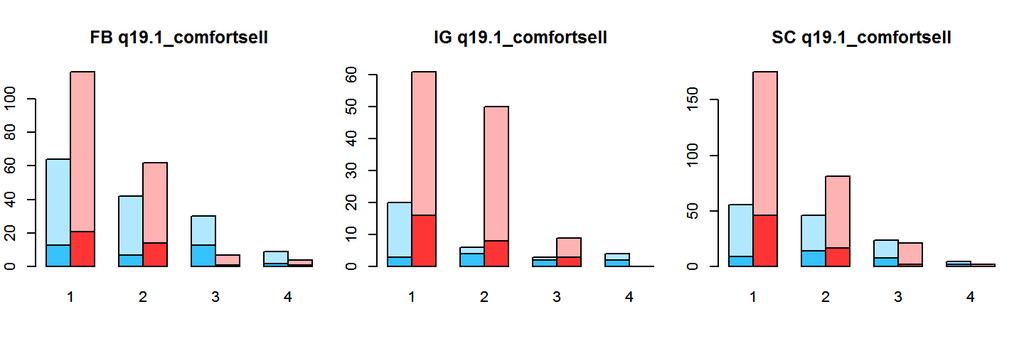

## Models

## L1. Concern, Q2 ~ Q7

Models with * did not converge properly. All models can potentially be improved significantly.

## Without demographic data

### Without interactions: Q7 ~ Q2 + digEdu + platform

Reduced: q7.1_editedprivacy ~ q2.1_nocare - 1 <environment: 0x0000000061765f20>

Coefficients:

Coefficients

| q2.1_nocare1 | 2.18 |
| --- | --- |
| q2.1_nocare2 | 0.71 |
| q2.1_nocare3 | -0.81 |

Reduced: q2.1_nocare ~ q7.1_editedprivacy - 1 <environment: 0x0000000061708c88>

Coefficients:

Coefficients

| q7.1_editedprivacy2 | 2.91 |
| --- | --- |
| q7.1_editedprivacy1 | 2.69 |
| q7.1_editedprivacy3 | 1.59 |

## With demographic data

### Without interactions: Q2 ~ Q7 + DigEdu + paltform + demo.dat

Reduced: q2.1_nocare ~ q7.1_editedprivacy + q3.1_gender - 1 <environment: 0x0000000061756b08>

Coefficients:

Coefficients

| q7.1_editedprivacy2 | 2.86 |
| --- | --- |
| q7.1_editedprivacy1 | 2.59 |
| q7.1_editedprivacy3 | 1.59 |
| q3.1_gendermand | 0.43 |

Reduced: q7.1_editedprivacy ~ q5.1_digedu + q2.1_nocare + q3.1_gender + q4.1_age + q5.1_digedu:q2.1_nocare + q5.1_digedu:q3.1_gender + q2.1_nocare:q4.1_age - 1 <environment: 0x0000000061700d88>

Coefficients:

Coefficients

| q2.1_nocare4 | 5.63 |
| --- | --- |
| q5.1_digedunej:q2.1_nocare4 | 4.17 |
| q2.1_nocare2 | 2.03 |
| q4.1_age | 0.33 |
| q5.1_digedunej:q2.1_nocare3 | 0.27 |
| q5.1_digeduja | 0.26 |
| q3.1_gendermand | 0.21 |
| q5.1_digedunej:q2.1_nocare2 | 0.07 |
| q2.1_nocare3:q4.1_age | -0.08 |
| q2.1_nocare2:q4.1_age | -0.20 |
| q5.1_digedunej:q3.1_gendermand | -0.61 |
| q2.1_nocare4:q4.1_age | -0.61 |
| q2.1_nocare3 | -1.65 |

## L2. Knowledge?!

Knowledge is defined as a factor whose levels are the combinations of the constituent questions (9-10, 11-12). For each pair of the questions 9,10 and 11-12 we create the derivative variables K1 and K2 such that for Q9 response i and Q10 response j the factor value of K1 is ij. K_1, K_2 have 16 elements each (4x4). In addition, based on the questions 9-19 we can build a wide range of derivative variables such as:

- knowledge (ignorance)
- awareness (naiveness)
- mindfulness (recklessness) etc

Below are tested the following 6 knowledge definitions:

## Models for K1 and K2

### Without interactions: Q2, Q7 ~ K1 + digedu + platform

Reduced: q2.1_nocare ~ q5.1_digedu - 1 <environment: 0x00000000616f3bd0>

Coefficients:

Coefficients

| q5.1_digeduja | -0.21 |
| --- | --- |

Reduced: q7.1_editedprivacy ~ q5.1_digedu - 1 <environment: 0x00000000616f3bd0>

Coefficients:

Coefficients

| q5.1_digeduja | 0.24 |
| --- | --- |

### With interactions: Q2, Q7 ~ (K2 + digedu + platform)^2

Reduced: q2.1_nocare ~ q5.1_digedu - 1 <environment: 0x00000000616e0a20>

Coefficients:

Coefficients

| q5.1_digeduja | -0.21 |
| --- | --- |

Reduced: q7.1_editedprivacy ~ q5.1_digedu - 1 <environment: 0x00000000616e0a20>

Coefficients:

Coefficients

| q5.1_digeduja | 0.24 |
| --- | --- |

### Without interactions: Q2_, Q7_ ~ K1 + digedu + platform + demo.dat

Reduced: q2.1_nocare ~ q5.1_digedu + q3.1_gender + q4.1_age + q6.1_school - 1 <environment: 0x00000000616d77e8>

Coefficients:

Coefficients

| q6.1_schoolknord | 28.78 |
| --- | --- |
| q6.1_schoolespergrde | 0.93 |
| q6.1_schoolgefion | 0.82 |
| q6.1_schoolfrederiksborg | 0.70 |
| q6.1_schoolvirum | 0.68 |
| q3.1_gendermand | 0.59 |
| q6.1_schoolnrum | 0.49 |
| q6.1_schoolegedal | 0.43 |
| q6.1_schoolsydkysten | 0.37 |
| q6.1_schoolgladsaxe | 0.31 |
| q6.1_schooljohannesskolen | 0.25 |
| q6.1_schoolsukkertoppen | 0.21 |
| q6.1_schoolkbenhavnsmediegymnasium | 0.20 |
| q6.1_schoolrestad | -0.03 |
| q4.1_age | -0.15 |
| q5.1_digeduja | -0.30 |

Reduced: q7.1_editedprivacy ~ q5.1_digedu + q3.1_gender + q4.1_age + q6.1_school - 1 <environment: 0x00000000616d77e8>

Coefficients:

Coefficients

| q6.1_schoolkbenhavnsmediegymnasium | 0.32 |
| --- | --- |
| q5.1_digeduja | 0.27 |
| q4.1_age | 0.21 |
| q6.1_schoolsukkertoppen | -0.23 |
| q6.1_schooljohannesskolen | -0.29 |
| q6.1_schoolrestad | -0.33 |
| q6.1_schoolgladsaxe | -0.34 |
| q6.1_schoolsydkysten | -0.34 |
| q6.1_schoolegedal | -0.34 |
| q3.1_gendermand | -0.45 |
| q6.1_schoolnrum | -0.45 |
| q6.1_schoolfrederiksborg | -0.62 |
| q6.1_schoolvirum | -0.86 |
| q6.1_schoolespergrde | -1.04 |
| q6.1_schoolgefion | -1.85 |
| q6.1_schoolknord | -28.78 |

## Models for K3 and K4

### With interactions: Q2, Q7 ~ (K3 + digedu + platform)^2

Reduced: q2.1_nocare ~ q5.1_digedu - 1 <environment: 0x00000000616c9308>

Coefficients:

Coefficients

| q5.1_digeduja | -0.21 |
| --- | --- |

Reduced: q7.1_editedprivacy ~ q5.1_digedu - 1 <environment: 0x00000000616c9308>

Coefficients:

Coefficients

| q5.1_digeduja | 0.24 |
| --- | --- |

### Without interactions: Q2, Q7 ~ K4 + digedu + paltform

Reduced: q2.1_nocare ~ q5.1_digedu - 1 <environment: 0x00000000616c0f50>

Coefficients:

Coefficients

| q5.1_digeduja | -0.21 |
| --- | --- |

Reduced: q7.1_editedprivacy ~ q5.1_digedu - 1 <environment: 0x00000000616c0f50>

Coefficients:

Coefficients

| q5.1_digeduja | 0.24 |
| --- | --- |

### With interactions: Q2_, Q7_ ~ (K3 + digedu + platform + demo.dat)^2

Reduced: q2.1_nocare ~ q5.1_digedu + q3.1_gender + q4.1_age + q6.1_school - 1 <environment: 0x00000000616b7288>

Coefficients:

Coefficients

| q6.1_schoolknord | 28.78 |
| --- | --- |
| q6.1_schoolespergrde | 0.93 |
| q6.1_schoolgefion | 0.82 |
| q6.1_schoolfrederiksborg | 0.70 |
| q6.1_schoolvirum | 0.68 |
| q3.1_gendermand | 0.59 |
| q6.1_schoolnrum | 0.49 |
| q6.1_schoolegedal | 0.43 |
| q6.1_schoolsydkysten | 0.37 |
| q6.1_schoolgladsaxe | 0.31 |
| q6.1_schooljohannesskolen | 0.25 |
| q6.1_schoolsukkertoppen | 0.21 |
| q6.1_schoolkbenhavnsmediegymnasium | 0.20 |
| q6.1_schoolrestad | -0.03 |
| q4.1_age | -0.15 |
| q5.1_digeduja | -0.30 |

Reduced: q7.1_editedprivacy ~ k3_ + q5.1_digedu + platform + q3.1_gender + q4.1_age + q6.1_school + q5.1_digedu:q3.1_gender + q3.1_gender:q4.1_age + q3.1_gender:q6.1_school - 1 <environment: 0x00000000616b7288>

Coefficients:

Coefficients

| q6.1_schoolkbenhavnsmediegymnasium | 22.16 |
| --- | --- |
| q3.1_gendermand:q6.1_schoolnrum | 1.42 |
| q3.1_gendermand:q6.1_schooljohannesskolen | 1.08 |
| q3.1_gendermand:q6.1_schoolsukkertoppen | 0.58 |
| q6.1_schoolrestad | 0.43 |
| k3_14 | 0.42 |
| q3.1_gendermand:q4.1_age | 0.25 |
| k3_34 | 0.20 |
| q4.1_age | 0.14 |
| platformig | 0.08 |
| q3.1_gendermand:q6.1_schoolvirum | 0.06 |
| k3_24 | 0.02 |
| q5.1_digedunej | -0.01 |
| k3_42 | -0.04 |
| q6.1_schoolgladsaxe | -0.06 |
| k3_43 | -0.10 |
| q6.1_schoolsydkysten | -0.12 |
| k3_12 | -0.20 |
| k3_41 | -0.22 |
| k3_31 | -0.25 |
| q3.1_gendermand:q6.1_schoolfrederiksborg | -0.27 |
| q3.1_gendermand:q6.1_schoolespergrde | -0.27 |
| q6.1_schoolegedal | -0.29 |
| platformsc | -0.32 |
| k3_13 | -0.34 |
| k3_33 | -0.40 |
| q3.1_gendermand:q6.1_schoolegedal | -0.43 |
| q6.1_schoolfrederiksborg | -0.58 |
| q6.1_schoolsukkertoppen | -0.62 |
| q6.1_schooljohannesskolen | -0.65 |
| k3_23 | -0.65 |
| q5.1_digedunej:q3.1_gendermand | -0.67 |
| q3.1_gendermand:q6.1_schoolgladsaxe | -0.69 |
| k3_32 | -0.74 |
| q3.1_gendermand:q6.1_schoolgefion | -0.86 |
| q6.1_schoolvirum | -0.96 |
| q6.1_schoolespergrde | -0.96 |
| k3_22 | -0.98 |
| q3.1_gendermand:q6.1_schoolsydkysten | -1.01 |
| k3_21 | -1.04 |
| q6.1_schoolnrum | -1.08 |
| q6.1_schoolgefion | -1.41 |
| k3_11 | -1.88 |
| q3.1_gendermand:q6.1_schoolrestad | -3.38 |
| q3.1_gendermand | -4.31 |
| q3.1_gendermand:q6.1_schoolkbenhavnsmediegymnasium | -22.29 |
| q6.1_schoolknord | -27.65 |

### Without interactions: Q2_, Q7_ ~ K4 + digedu + platform + demo.dat

Reduced: q2.1_nocare ~ q5.1_digedu + q3.1_gender + q4.1_age + q6.1_school - 1 <environment: 0x00000000616a5790>

Coefficients:

Coefficients

| q6.1_schoolknord | 28.78 |
| --- | --- |
| q6.1_schoolespergrde | 0.93 |
| q6.1_schoolgefion | 0.82 |
| q6.1_schoolfrederiksborg | 0.70 |
| q6.1_schoolvirum | 0.68 |
| q3.1_gendermand | 0.59 |
| q6.1_schoolnrum | 0.49 |
| q6.1_schoolegedal | 0.43 |
| q6.1_schoolsydkysten | 0.37 |
| q6.1_schoolgladsaxe | 0.31 |
| q6.1_schooljohannesskolen | 0.25 |
| q6.1_schoolsukkertoppen | 0.21 |
| q6.1_schoolkbenhavnsmediegymnasium | 0.20 |
| q6.1_schoolrestad | -0.03 |
| q4.1_age | -0.15 |
| q5.1_digeduja | -0.30 |

Reduced: q7.1_editedprivacy ~ q5.1_digedu + q3.1_gender + q4.1_age + q6.1_school - 1 <environment: 0x00000000616a5790>

Coefficients:

Coefficients

| q6.1_schoolkbenhavnsmediegymnasium | 0.32 |
| --- | --- |
| q5.1_digeduja | 0.27 |
| q4.1_age | 0.21 |
| q6.1_schoolsukkertoppen | -0.23 |
| q6.1_schooljohannesskolen | -0.29 |
| q6.1_schoolrestad | -0.33 |
| q6.1_schoolgladsaxe | -0.34 |
| q6.1_schoolsydkysten | -0.34 |
| q6.1_schoolegedal | -0.34 |
| q3.1_gendermand | -0.45 |
| q6.1_schoolnrum | -0.45 |
| q6.1_schoolfrederiksborg | -0.62 |
| q6.1_schoolvirum | -0.86 |
| q6.1_schoolespergrde | -1.04 |
| q6.1_schoolgefion | -1.85 |
| q6.1_schoolknord | -28.78 |

## Models for K5 and K6

### With interactions: Q2, Q7 ~ (K5 + digedu + platform)^2

Reduced: q2.1_nocare ~ q5.1_digedu - 1 <environment: 0x000000006168e0e8>

Coefficients:

Coefficients

| q5.1_digeduja | -0.21 |
| --- | --- |

Reduced: q7.1_editedprivacy ~ k5_ + q5.1_digedu + platform - 1 <environment: 0x000000006168e0e8>

Coefficients:

Coefficients

| platformig | 0.14 |
| --- | --- |
| k5_34 | 0.03 |
| k5_12 | -0.06 |
| platformsc | -0.20 |
| k5_14 | -0.25 |
| k5_42 | -0.28 |
| q5.1_digedunej | -0.30 |
| k5_23 | -0.39 |
| k5_11 | -0.41 |
| k5_24 | -0.60 |
| k5_33 | -0.67 |
| k5_21 | -0.68 |
| k5_13 | -0.68 |
| k5_32 | -0.73 |
| k5_22 | -0.97 |
| k5_31 | -1.16 |
| k5_43 | -1.20 |
| k5_41 | -4.19 |

### Without interactions: Q2, Q7 ~ K6 + digedu + platform

Reduced: q2.1_nocare ~ q5.1_digedu - 1 <environment: 0x0000000061683590>

Coefficients:

Coefficients

| q5.1_digeduja | -0.21 |
| --- | --- |

Reduced: q7.1_editedprivacy ~ q5.1_digedu - 1 <environment: 0x0000000061683590>

Coefficients:

Coefficients

| q5.1_digeduja | 0.24 |
| --- | --- |

### With interactions: Q2_, Q7_ ~ (K5 + digedu + platform + demo.dat)^2

Reduced: q2.1_nocare ~ q5.1_digedu + q3.1_gender + q4.1_age + q6.1_school - 1 <environment: 0x0000000061786cb8>

Coefficients:

Coefficients

| q6.1_schoolknord | 28.78 |
| --- | --- |
| q6.1_schoolespergrde | 0.93 |
| q6.1_schoolgefion | 0.82 |
| q6.1_schoolfrederiksborg | 0.70 |
| q6.1_schoolvirum | 0.68 |
| q3.1_gendermand | 0.59 |
| q6.1_schoolnrum | 0.49 |
| q6.1_schoolegedal | 0.43 |
| q6.1_schoolsydkysten | 0.37 |
| q6.1_schoolgladsaxe | 0.31 |
| q6.1_schooljohannesskolen | 0.25 |
| q6.1_schoolsukkertoppen | 0.21 |
| q6.1_schoolkbenhavnsmediegymnasium | 0.20 |
| q6.1_schoolrestad | -0.03 |
| q4.1_age | -0.15 |
| q5.1_digeduja | -0.30 |

Reduced: q7.1_editedprivacy ~ k5_ + q5.1_digedu + q3.1_gender + q4.1_age + q6.1_school + q5.1_digedu:q3.1_gender + q3.1_gender:q4.1_age + q3.1_gender:q6.1_school - 1 <environment: 0x0000000061786cb8>

Coefficients:

Coefficients

| q6.1_schoolkbenhavnsmediegymnasium | 22.11 |
| --- | --- |
| q3.1_gendermand:q6.1_schoolnrum | 1.44 |
| q3.1_gendermand:q6.1_schooljohannesskolen | 1.42 |
| q3.1_gendermand:q6.1_schoolsukkertoppen | 0.55 |
| q6.1_schoolrestad | 0.55 |
| q3.1_gendermand:q4.1_age | 0.25 |
| q4.1_age | 0.14 |
| k5_34 | -0.01 |
| q5.1_digedunej | -0.01 |
| q6.1_schoolsydkysten | -0.04 |
| q3.1_gendermand:q6.1_schoolvirum | -0.05 |
| q6.1_schoolgladsaxe | -0.09 |
| k5_42 | -0.19 |
| q6.1_schoolegedal | -0.27 |
| q3.1_gendermand:q6.1_schoolegedal | -0.32 |
| q3.1_gendermand:q6.1_schoolfrederiksborg | -0.34 |
| q3.1_gendermand:q6.1_schoolespergrde | -0.36 |
| k5_12 | -0.37 |
| q6.1_schoolfrederiksborg | -0.53 |
| k5_11 | -0.53 |
| q6.1_schoolsukkertoppen | -0.54 |
| k5_14 | -0.57 |
| q3.1_gendermand:q6.1_schoolgladsaxe | -0.59 |
| k5_21 | -0.62 |
| k5_24 | -0.64 |
| k5_23 | -0.64 |
| q6.1_schooljohannesskolen | -0.65 |
| q5.1_digedunej:q3.1_gendermand | -0.66 |
| k5_33 | -0.73 |
| q3.1_gendermand:q6.1_schoolgefion | -0.74 |
| k5_32 | -0.89 |
| q6.1_schoolvirum | -0.90 |
| q6.1_schoolespergrde | -0.93 |
| k5_43 | -1.07 |
| k5_13 | -1.12 |
| q6.1_schoolnrum | -1.14 |
| k5_31 | -1.23 |
| k5_22 | -1.25 |
| q6.1_schoolgefion | -1.37 |
| q3.1_gendermand:q6.1_schoolsydkysten | -1.69 |
| q3.1_gendermand:q6.1_schoolrestad | -3.72 |
| q3.1_gendermand | -4.27 |
| k5_41 | -4.60 |
| q3.1_gendermand:q6.1_schoolkbenhavnsmediegymnasium | -21.94 |
| q6.1_schoolknord | -27.79 |

### Without interactions: Q2_, Q7_ ~ K6 + digedu + platform + demo.dat

Reduced: q2.1_nocare ~ q5.1_digedu + q3.1_gender + q4.1_age + q6.1_school - 1 <environment: 0x0000000061672560>

Coefficients:

Coefficients

| q6.1_schoolknord | 28.78 |
| --- | --- |
| q6.1_schoolespergrde | 0.93 |
| q6.1_schoolgefion | 0.82 |
| q6.1_schoolfrederiksborg | 0.70 |
| q6.1_schoolvirum | 0.68 |
| q3.1_gendermand | 0.59 |
| q6.1_schoolnrum | 0.49 |
| q6.1_schoolegedal | 0.43 |
| q6.1_schoolsydkysten | 0.37 |
| q6.1_schoolgladsaxe | 0.31 |
| q6.1_schooljohannesskolen | 0.25 |
| q6.1_schoolsukkertoppen | 0.21 |
| q6.1_schoolkbenhavnsmediegymnasium | 0.20 |
| q6.1_schoolrestad | -0.03 |
| q4.1_age | -0.15 |
| q5.1_digeduja | -0.30 |

Reduced: q7.1_editedprivacy ~ q5.1_digedu + q3.1_gender + q4.1_age + q6.1_school - 1 <environment: 0x0000000061672560>

Coefficients:

Coefficients

| q6.1_schoolkbenhavnsmediegymnasium | 0.32 |
| --- | --- |
| q5.1_digeduja | 0.27 |
| q4.1_age | 0.21 |
| q6.1_schoolsukkertoppen | -0.23 |
| q6.1_schooljohannesskolen | -0.29 |
| q6.1_schoolrestad | -0.33 |
| q6.1_schoolgladsaxe | -0.34 |
| q6.1_schoolsydkysten | -0.34 |
| q6.1_schoolegedal | -0.34 |
| q3.1_gendermand | -0.45 |
| q6.1_schoolnrum | -0.45 |
| q6.1_schoolfrederiksborg | -0.62 |
| q6.1_schoolvirum | -0.86 |
| q6.1_schoolespergrde | -1.04 |
| q6.1_schoolgefion | -1.85 |
| q6.1_schoolknord | -28.78 |